# IMDB

```python
%reload_ext autoreload
%autoreload 2
%matplotlib inline
```

```python
from fastai.text import *
```

## Preparing the data

First let's download the dataset we are going to study. The [dataset](http://ai.stanford.edu/~amaas/data/sentiment/) has been curated by Andrew Maas et al. and contains a total of 100,000 reviews on IMDB. 25,000 of them are labelled as positive and negative for training, another 25,000 are labelled for testing (in both cases they are highly polarized). The remaning 50,000 is an additional unlabelled data (but we will find a use for it nonetheless).

We'll begin with a sample we've prepared for you, so that things run quickly before going over the full dataset.

```python
path = untar_data(URLs.IMDB_SAMPLE)
path.ls()
```

```
[PosixPath('/storage/imdb_sample/data_save.pkl'),
 PosixPath('/storage/imdb_sample/texts.csv')]
```

It only contains one csv file, let's have a look at it.

```python
df = pd.read_csv(path/'texts.csv')
df.head()
```

|  | label | text | is_valid |
| --- | --- | --- | --- |
| 0 | negative | Un-bleeping-believable! Meg Ryan doesn't even ... | False |
| 1 | positive | This is a extremely well-made film. The acting... | False |
| 2 | negative | Every once in a long while a movie will come a... | False |
| 3 | positive | Name just says it all. I watched this movie wi... | False |
| 4 | negative | This movie succeeds at being one of the most u... | False |

```python
df['text'][1]
```

```
'This is a extremely well-made film. The acting, script and camera-work are all first-rate. The music is good, too, though it is mostly early in the film, when things are still relatively cheery. There are no really superstars in the cast, though several faces will be familiar. The entire cast does …
```

It contains one line per review, with the label ('negative' or 'positive'), the text and a flag to determine if it should be part of the validation set or the training set. If we ignore this flag, we can create a DataBunch containing this data in one line of code:

```python
data_lm = TextDataBunch.from_csv(path, 'texts.csv')
```

By executing this line a process was launched that took a bit of time. Let's dig a bit into it. Images could be fed (almost) directly into a model because they're just a big array of pixel values that are floats between 0 and 1. A text is composed of words, and we can't apply mathematical functions to them directly. We first have to convert them to numbers. This is done in two differents steps: tokenization and numericalization. A `TextDataBunch` does all of that behind the scenes for you.

Before we delve into the explanations, let's take the time to save the things that were calculated.

```python
data_lm.save()
```

Next time we launch this notebook, we can skip the cell above that took a bit of time (and that will take a lot more when you get to the full dataset) and load those results like this:

```python
data = load_data(path)
```

### Tokenization

The first step of processing we make the texts go through is to split the raw sentences into words, or more exactly tokens. The easiest way to do this would be to split the string on spaces, but we can be smarter:

- we need to take care of punctuation
- some words are contractions of two different words, like isn't or don't
- we may need to clean some parts of our texts, if there's HTML code for instance

To see what the tokenizer had done behind the scenes, let's have a look at a few texts in a batch.

```python
data = TextClasDataBunch.from_csv(path, 'texts.csv')
data.show_batch()
```

| text | target |
| --- | --- |
| xxbos xxmaj raising xxmaj victor xxmaj vargas : a xxmaj review \n \n xxmaj you know , xxmaj raising xxmaj victor xxmaj vargas is like sticking your hands into a big , steaming bowl of xxunk . xxmaj it… | negative |
| xxbos xxup the xxup shop xxup around xxup the xxup corner is one of the xxunk and most feel - good romantic comedies ever made . xxmaj there 's just no getting around that , and it 's hard to actually… | positive |
| xxbos xxmaj now that xxmaj che(2008 ) has finished its relatively short xxmaj australian cinema run ( extremely limited xxunk screen in xxmaj sydney , after xxunk ) , i can xxunk join both xxunk of " … | negative |
| xxbos xxmaj this film sat on my xxmaj tivo for weeks before i watched it . i dreaded a self - indulgent xxunk flick about relationships gone bad . i was wrong ; this was an xxunk xxunk into the screwe… | positive |
| xxbos xxmaj many neglect that this is n't just a classic due to the fact that it 's the first xxup 3d game , or even the first xxunk - up . xxmaj it 's also one of the first stealth games , one of the… | positive |

The texts are truncated at 100 tokens for more readability. We can see that it did more than just split on space and punctuation symbols:

- the "'s" are grouped together in one token
- the contractions are separated like this: "did", "n't"
- content has been cleaned for any HTML symbol and lower cased
- there are several special tokens (all those that begin by xx), to replace unknown tokens (see below) or to introduce different text fields (here we only have one).

### Numericalization

Once we have extracted tokens from our texts, we convert to integers by creating a list of all the words used. We only keep the ones that appear at least twice with a maximum vocabulary size of 60,000 (by default) and replace the ones that don't make the cut by the unknown token `UNK`.

The correspondance from ids to tokens is stored in the `vocab` attribute of our datasets, in a dictionary called `itos` (for int to string).

```python
data.vocab.itos[:10]
```

```
['xxunk',
 'xxpad',
 'xxbos',
 'xxeos',
 'xxfld',
 'xxmaj',
 'xxup',
 'xxrep',
 'xxwrep',
 'the']
```

And if we look at what a what's in our datasets, we'll see the tokenized text as a representation:

```python
data.train_ds[0][0]
```

```
Text xxbos xxmaj andy xxmaj goldsworthy is a xxunk master of the first order , expressing the xxmaj way through his xxunk xxunk art . xxmaj indeed , time and change is what his work is fundamentally about . i bought his first book several years ago and my family has xxunk at it many times . xxmaj so…
```

But the underlying data is all numbers

```python
data.train_ds[0][0].data[:10]
```

```
array([   2,    5, 1773,    5, 5957,   16,   13,    0, 1953,   14])
```

### With the data block API

We can use the data block API with NLP and have a lot more flexibility than what the default factory methods offer. In the previous example for instance, the data was randomly split between train and validation instead of reading the third column of the csv.

With the data block API though, we have to manually call the tokenize and numericalize steps. This allows more flexibility, and if you're not using the defaults from fastai, the various arguments to pass will appear in the step they're revelant, so it'll be more readable.

```python
# split into train and validation, and label using columns.
data = (TextList.from_csv(path, 'texts.csv', cols='text')
                .split_from_df(col=2)
                .label_from_df(cols=0)
                .databunch())
```

## Language model

Note that language models can use a lot of GPU, so you may need to decrease batchsize here.

```python
bs=12
```

Now let's grab the full dataset for what follows.

```python
path = untar_data(URLs.IMDB)
path.ls()
```

```python
(path/'train').ls()
```

The reviews are in a training and test set following an imagenet structure. The only difference is that there is an `unsup` folder on top of `train` and `test` that contains the unlabelled data.

We're not going to train a model that classifies the reviews from scratch. Like in computer vision, we'll use a model pretrained on a bigger dataset (a cleaned subset of wikipedia called [wikitext-103](https://einstein.ai/research/blog/the-wikitext-long-term-dependency-language-modeling-dataset)). That model has been trained to guess what the next word is, its input being all the previous words. It has a recurrent structure and a hidden state that is updated each time it sees a new word. This hidden state thus contains information about the sentence up to that point.

We are going to use that 'knowledge' of the English language to build our classifier, but first, like for computer vision, we need to fine-tune the pretrained model to our particular dataset. Because the English of the reviews left by people on IMDB isn't the same as the English of wikipedia, we'll need to adjust the parameters of our model by a little bit. Plus there might be some words that would be extremely common in the reviews dataset but would be barely present in wikipedia, and therefore might not be part of the vocabulary the model was trained on.

This is where the unlabelled data is going to be useful to us, as we can use it to fine-tune our model. Let's create our data object with the data block API (next line takes a few minutes).

```python
data_lm = (TextList.from_folder(path)
           #Inputs: all the text files in path
            .filter_by_folder(include=['train', 'test', 'unsup'])
           #We may have other temp folders that contain text files so we only keep what's in train and test
            .split_by_rand_pct(0.1)
           #We randomly split and keep 10% (10,000 reviews) for validation
            .label_for_lm()
           #We want to do a language model so we label accordingly
            .databunch(bs=bs))
data_lm.save('data_lm.pkl')
```

We have to use a special kind of `TextDataBunch` for the language model, that ignores the labels (that's why we put 0 everywhere), will shuffle the texts at each epoch before concatenating them all together (only for training, we don't shuffle for the validation set) and will send batches that read that text in order with targets that are the next word in the sentence.

The line before being a bit long, we want to load quickly the final ids by using the following cell.

```python
data_lm = load_data(path, 'data_lm.pkl', bs=bs)
```

```python
data_lm.show_batch()
```

| idx | text |
| --- | --- |
| 0 | original script that xxmaj david xxmaj dhawan has worked on . xxmaj this one was a complete bit y bit rip off xxmaj hitch . i have nothing against remakes as such , but this one is just so lousy that … |
| 1 | ' classic ' xxmaj the xxmaj big xxmaj doll xxmaj house ' , which takes xxmaj awful to a whole new level . i can heartily recommend these two xxunk as a double - bill . xxmaj you 'll laugh yourself sil… |
| 2 | of xxmaj european cinema 's most quietly disturbing sociopaths and one of the most memorable finales of all time ( shamelessly stolen by xxmaj tarantino for xxmaj kill xxmaj bill xxmaj volume xxmaj tw… |
| 3 | but even xxmaj martin xxmaj short managed a distinct , supporting character . ) \n\n i can understand the attraction of an imaginary world created in a good romantic comedy . xxmaj but this film is th… |
| 4 | xxmaj pre - xxmaj code film . xxbos xxmaj here 's a decidedly average xxmaj italian post apocalyptic take on the hunting / killing humans for sport theme ala xxmaj the xxmaj most xxmaj dangerous xxmaj… |

We can then put this in a learner object very easily with a model loaded with the pretrained weights. They'll be downloaded the first time you'll execute the following line and stored in `~/.fastai/models/` (or elsewhere if you specified different paths in your config file).

```python
# this creates an AWD-LSTM model (https://docs.fast.ai/text.models.html#AWD_LSTM)
# This model is just the decoder which can then be plugged into an encoder for language modelling, or
# a classifier for classification.
# `drop_mult` sets the amount of dropout - less than the default amount of regularization
learn = language_model_learner(data_lm, AWD_LSTM, drop_mult=0.3)
```

```python
learn.lr_find()
```

```
LR Finder is complete, type {learner_name}.recorder.plot() to see the graph.
```

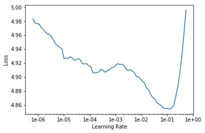

```python
learn.recorder.plot(skip_end=15)
```

```python
# here we are fine-tuning the last layers of the LSTM
learn.fit_one_cycle(1, 1e-2, moms=(0.8,0.7))
```

Total time: 16:47

| epoch | train_loss | valid_loss | accuracy |
| --- | --- | --- | --- |
| 1 | 4.232034 | 4.060273 | 0.292894 |

```python
learn.save('fit_head')
```

```python
learn.load('fit_head');
```

To complete the fine-tuning, we can then unfeeze and launch a new training.

```python
learn.unfreeze()
```

```python
# this takes 2-3 hours on a big GPU
# although this model takes a while to learn, it's THE ONLY ONE WE NEED FOR THIS SPECIFIC DOMAIN/DATASET
learn.fit_one_cycle(10, 1e-3, moms=(0.8,0.7))

# accuracy 0.3 - we expect to predict the next word in a review correctly about 34% of the time.
# For restricted vocabulary we expect this to be a lot higher.
```

Total time: 3:08:33

| epoch | train_loss | valid_loss | accuracy |
| --- | --- | --- | --- |
| 1 | 3.958489 | 3.885153 | 0.310139 |
| 2 | 3.871605 | 3.814774 | 0.319821 |
| 3 | 3.804589 | 3.767966 | 0.325793 |
| 4 | 3.771248 | 3.729666 | 0.330175 |
| 5 | 3.677534 | 3.699244 | 0.333532 |
| 6 | 3.644140 | 3.674071 | 0.336564 |
| 7 | 3.603597 | 3.655099 | 0.338747 |
| 8 | 3.524271 | 3.641979 | 0.340568 |
| 9 | 3.505476 | 3.636194 | 0.341246 |
| 10 | 3.461232 | 3.635963 | 0.341371 |

```python
learn.save('fine_tuned')
```

How good is our model? Well let's try to see what it predicts after a few given words.

```python
learn.load('fine_tuned');
```

```python
TEXT = "I liked this movie because"
N_WORDS = 40
N_SENTENCES = 2
```

```python
print("\n".join(learn.predict(TEXT, N_WORDS, temperature=0.75) for _ in range(N_SENTENCES)))
```

```
I liked this movie because of the cool scenery and the high level of xxmaj british hunting . xxmaj the only thing this movie has going for it is the horrible acting and no script . xxmaj the movie was a big disappointment . xxmaj
I liked this movie because it was one of the few movies that made me laugh so hard i did n't like it . xxmaj it was a hilarious film and it was very entertaining .

 xxmaj the acting was great , i 'm
```

We have to save not only the model, but also its encoder, the part that's responsible for creating and updating the hidden state. For the next part, we don't care about the part that tries to guess the next word.

```python
# just saving the encoder part - understanding the sentence rather than generating word predictions
learn.save_encoder('fine_tuned_enc')
```